# Lesson 4A: Examining Categorical Variables

DS 01-101: In-Depth Introduction to Data Science (Spring 2026)

Author

Affiliation

Hung Tong

Rowan University

## Topics

- Basic variable types
- Frequency distribution, mode, and bar plot
- Stacked and side-by-side bar plot

## Basic variable types

- Data are commonly organized into a **data matrix**. In this format, each row is an **observation** and each column is a **variable** or **feature**.

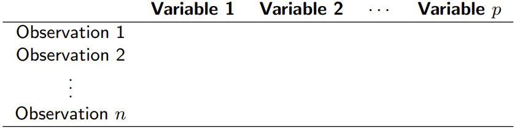

- Roughly speaking, a variable can be **numerical** or **categorical**.

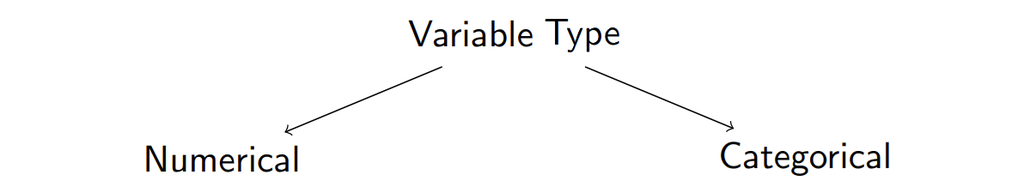

- A **numerical variable** represents numbers that are meaningful to add, subtract, or take averages.
- A **categorical variable** refers to specific categories that describe a characteristic.

## Examining a categorical variable

- A **frequency distribution** is a tabular summary of data showing the number (frequency) of observations in each categories.

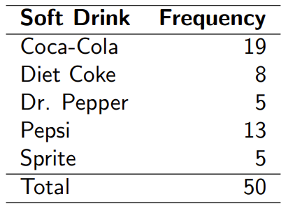

- The **mode** is the category that appears the most. There can be multiple modes.
- A **bar plot** visualizes the frequency distribution of a categorical variable using bars of different heights.

## Examining two categorical variables

- A **contingency table** is a tabular summary of data for two categorical variables showing the frequency of their shared characteristics.

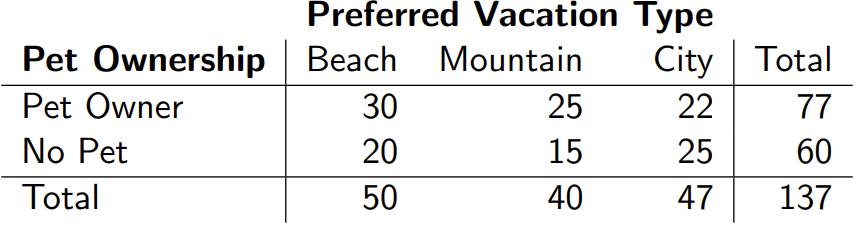

- **Stacked bar plot** can be used to visualize the contingency table.

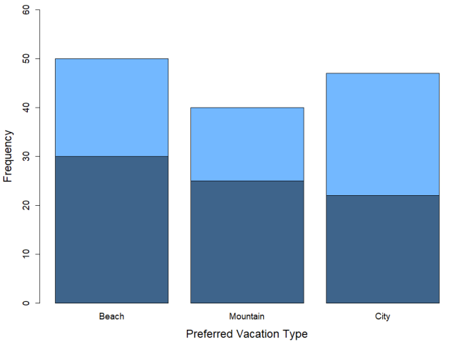

- **Side-by-side bar plot** is also a good option.

[figure not shown]